# BAB 4 - Implementasi dan Hasil Analisis

Notebook ini disusun untuk membantu penulisan BAB 4 secara bertahap dan lebih rapi. Setiap bagian dibuat mengikuti alur penelitian yang sudah ditetapkan, mulai dari data hasil cleaning sampai evaluasi model.

Fokus utama notebook ini adalah:

- menampilkan proses yang benar-benar dilakukan pada data,
- menyimpan hasil tiap tahap secara sistematis,
- memudahkan penulisan narasi hasil penelitian ke dalam skripsi.

## Alur BAB 4

Urutan pembahasan pada BAB 4 dapat mengikuti langkah berikut:

1. Menyiapkan dan membaca dataset hasil cleaning.
2. Menampilkan gambaran umum dataset.
3. Melakukan data cleansing.
4. Menampilkan visualisasi data sebelum preprocessing.
5. Melakukan case folding.
6. Melakukan normalization.
7. Melakukan stopword removal.
8. Menjelaskan tokenisasi otomatis pada TF-IDF.
9. Melakukan stemming dan melihat visualisasi setelah preprocessing.
10. Menentukan label yang dipakai dalam klasifikasi.
11. Membagi data menjadi train dan test.
12. Menjalankan model baseline TF-IDF + SVM.
13. Menjalankan model fine-tuning IndoBERT.
14. Menjalankan model fine-tuning IndoBERTweet.
15. Mengevaluasi hasil setiap model.
16. Membandingkan performa model dan memilih model terbaik.

Catatan: bila pada tahap tertentu proses belum dijalankan, bagian tersebut tetap bisa disiapkan dulu agar struktur BAB 4 tetap utuh.

```python
# Library dasar yang dipakai di beberapa tahap analisis.
# Jika ada paket yang belum terpasang, instalasi bisa dilakukan terpisah.

import re
from collections import Counter
from pathlib import Path

import matplotlib.pyplot as plt
import numpy as np
import pandas as pd

from sklearn.model_selection import train_test_split
from sklearn.feature_extraction.text import TfidfVectorizer
from sklearn.svm import LinearSVC
from sklearn.pipeline import Pipeline
from sklearn.metrics import classification_report, confusion_matrix, accuracy_score

try:
    import seaborn as sns
    SEABORN_AVAILABLE = True
except ImportError:
    SEABORN_AVAILABLE = False

try:
    from wordcloud import WordCloud
    WORDCLOUD_AVAILABLE = True
except ImportError:
    WORDCLOUD_AVAILABLE = False

pd.set_option('display.max_colwidth', 200)
```

## 4.1 Menyiapkan Dataset

Pada tahap ini, dataset final dibaca ke dalam notebook. File yang digunakan merupakan versi data yang sudah dirapikan dan hanya menyisakan kolom yang diperlukan untuk analisis.

File utama yang dipakai pada notebook ini adalah:

- `outputs/Dataset_Skripsi_Finals_Bismillah.csv`

File tersebut berisi 5.001 data yang sudah memiliki label manual. Karena struktur dataset sudah disederhanakan, pembahasan pada bagian berikutnya akan lebih fokus pada kolom inti seperti teks, id, dan hasil pelabelan manual.

```python
# Menentukan lokasi file dataset yang akan dipakai.

data_path = Path('outputs/Dataset_Skripsi_Finals_Bismillah.csv')
df = pd.read_csv(data_path, sep=';')

print(f'Jumlah baris: {len(df)}')
print(f'Jumlah kolom: {df.shape[1]}')
df.head()
```

```
Jumlah baris: 5001
Jumlah kolom: 10
```

|  | conversation_id_str | created_at | favorite_count | full_text | manual_labeling | id_str | lang | status_id | tweet_url | user_id_str |
| --- | --- | --- | --- | --- | --- | --- | --- | --- | --- | --- |
| 0 | 2,01E+23 | Tue Dec 30 11:05:48 +0000 2025 | 0 | @DesWira15 @FaGtng Hilirisasi digital adalah strategi untuk mengolah bahan baku digital seperti data menjadi produk bernilai tinggi mirip hilirisasi industri. Contoh: bangun data center kembangkan... | peluang | 2,01E+18 | in | 2,01E+18 | https://x.com/i/status/2005958494277542173 | 1,72E+18 |
| 1 | 2,01E+23 | Tue Dec 30 04:13:26 +0000 2025 | 7 | @FaGtng SMA SAJA TIDAK LULUS KERJA DICARIKAN ORANG TUA DAN PAMANNYA .... PAKAI NGOMONG TENTANG AI HILIRISASI DIGITAL DAN MENCIPTAKAN LAPANGAN KERJA .... DASAR KELUARGA PENIPU .... | peluang | 2,01E+18 | in | 2,01E+18 | https://x.com/i/status/2005854719084798223 | 240207283 |
| 2 | 2,01E+23 | Mon Dec 29 23:02:27 +0000 2025 | 0 | gausah marah atau nganggap gue arogan atau apapun nyatanya yang tergantikan AI katanya itu ya karna emang mereka ga punya skill ga ada AI pun belom tentu bisa bersaing ditengah lapangan kerja yang... | ancaman | 2,01E+18 | in | 2,01E+18 | https://x.com/i/status/2005776457826816291 | 3123971739 |
| 3 | 2,00E+23 | Tue Dec 23 09:11:59 +0000 2025 | 3 | @Duren___ @NgkongRoses Padahal ai dan codinglah yang akan membuat lapangan kerja mengecil? | ancaman | 2,00E+18 | in | 2,00E+18 | https://x.com/i/status/2003393137667080672 | 1,61E+18 |
| 4 | 2,00E+23 | Mon Dec 22 14:11:30 +0000 2025 | 2 | @Ary_PrasKe2 Bu guru rupanya gak paham apa yg dikatakan mas wapres. AI dan Coding adalah wujud dari 19 jta lapangan kerja yg dijanjikan AI dan Coding diperuntukan bagi pengangguran sebagai ganti p... | ancaman | 2,00E+18 | in | 2,00E+18 | https://x.com/i/status/2003106121935172023 | 1,90E+18 |

## 4.2 Gambaran Umum Dataset

Bagian ini digunakan untuk menampilkan struktur dasar dataset yang dipakai dalam penelitian. Fokus utama pada tahap ini adalah melihat nama setiap kolom dan tipe data yang terbaca saat dataset dimuat ke dalam Python.

Informasi ini penting karena akan menjadi dasar untuk menentukan kolom mana yang dipakai pada tahap labeling, preprocessing, dan pemodelan.

```python
# Menampilkan daftar kolom beserta tipe datanya.

kolom_info = pd.DataFrame({
    'nama_kolom': df.columns,
    'tipe_data': df.dtypes.astype(str).values
})

kolom_info
```

|  | nama_kolom | tipe_data |
| --- | --- | --- |
| 0 | conversation_id_str | str |
| 1 | created_at | str |
| 2 | favorite_count | int64 |
| 3 | full_text | str |
| 4 | manual_labeling | str |
| 5 | id_str | str |
| 6 | lang | str |
| 7 | status_id | str |
| 8 | tweet_url | str |
| 9 | user_id_str | str |

## 4.3 Data Cleansing

Sebelum masuk ke tahap preprocessing, data perlu diperiksa terlebih dahulu untuk memastikan kualitas dasarnya sudah baik. Pada tahap ini, pemeriksaan difokuskan pada kolom teks utama, yaitu `full_text`, serta kondisi label manual yang akan dipakai pada tahap klasifikasi.

Beberapa hal dasar yang diperiksa pada tahap cleansing adalah:

- apakah masih ada nilai kosong pada `full_text`,
- apakah masih ada nilai kosong pada `manual_labeling`,
- dan apakah masih terdapat data duplikat berdasarkan isi `full_text`.

```python
# Pemeriksaan dasar pada tahap data cleansing.

df['manual_labeling'] = df['manual_labeling'].astype(str).str.strip().str.lower()
df.loc[df['manual_labeling'].isin(['', 'nan']), 'manual_labeling'] = np.nan

ringkasan_cleansing = pd.DataFrame({
    'pemeriksaan': [
        'Jumlah data',
        'full_text kosong',
        'manual_labeling kosong',
        'Duplikat full_text'
    ],
    'hasil': [
        len(df),
        df['full_text'].isna().sum(),
        df['manual_labeling'].isna().sum(),
        df['full_text'].duplicated().sum()
    ]
})

ringkasan_cleansing
```

|  | pemeriksaan | hasil |
| --- | --- | --- |
| 0 | Jumlah data | 5001 |
| 1 | full_text kosong | 0 |
| 2 | manual_labeling kosong | 0 |
| 3 | Duplikat full_text | 0 |

## 4.3.1 Visualisasi Data Sebelum Preprocessing

Setelah tahap data cleansing, visualisasi awal dilakukan untuk melihat gambaran umum kata-kata yang sering muncul pada dataset sebelum preprocessing. Visualisasi ini ditampilkan dalam bentuk word cloud dan distribusi frekuensi kata.

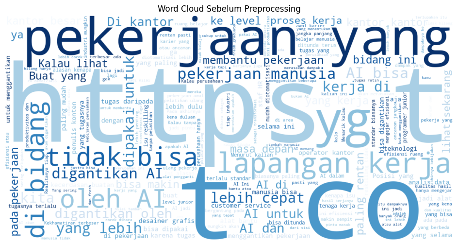

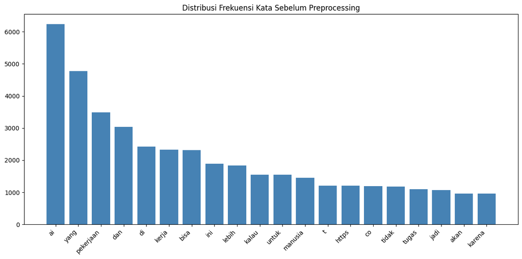

|  | kata | frekuensi |
| --- | --- | --- |
| 0 | ai | 6231 |
| 1 | yang | 4770 |
| 2 | pekerjaan | 3484 |
| 3 | dan | 3036 |
| 4 | di | 2418 |
| 5 | kerja | 2333 |
| 6 | bisa | 2312 |
| 7 | ini | 1888 |
| 8 | lebih | 1836 |
| 9 | kalau | 1546 |
| 10 | untuk | 1544 |
| 11 | manusia | 1447 |
| 12 | t | 1210 |
| 13 | https | 1203 |
| 14 | co | 1199 |
| 15 | tidak | 1182 |
| 16 | tugas | 1102 |
| 17 | jadi | 1072 |
| 18 | akan | 964 |
| 19 | karena | 955 |

```python
# Menyiapkan teks sebelum preprocessing untuk visualisasi awal.

text_before = ' '.join(df['full_text'].dropna().astype(str))
tokens_before = re.findall(r'\b\w+\b', text_before.lower())
freq_before = pd.DataFrame(Counter(tokens_before).most_common(20), columns=['kata', 'frekuensi'])

if WORDCLOUD_AVAILABLE:
    plt.figure(figsize=(12, 6))
    wc = WordCloud(width=1200, height=600, background_color='white', colormap='Blues').generate(text_before)
    plt.imshow(wc, interpolation='bilinear')
    plt.axis('off')
    plt.title('Word Cloud Sebelum Preprocessing')
    plt.show()
else:
    print('WordCloud belum terpasang. Visual word cloud dilewati sementara.')

plt.figure(figsize=(12, 6))
plt.bar(freq_before['kata'], freq_before['frekuensi'], color='steelblue')
plt.title('Distribusi Frekuensi Kata Sebelum Preprocessing')
plt.xticks(rotation=45, ha='right')
plt.tight_layout()
plt.show()

freq_before
```

## 4.4 Case Folding

Case folding dilakukan dengan mengubah seluruh huruf pada teks menjadi huruf kecil. Langkah ini berguna untuk menyamakan bentuk kata sehingga model tidak menganggap kata yang sama sebagai token yang berbeda hanya karena perbedaan kapital.

```python
# Mengubah seluruh teks menjadi huruf kecil.
# Hasil tahap ini disimpan pada kolom text_casefold.

df['text_casefold'] = df['full_text'].astype(str).str.lower()

display(df[['full_text', 'text_casefold']].head(10))
```

|  | full_text | text_casefold |
| --- | --- | --- |
| 0 | @DesWira15 @FaGtng Hilirisasi digital adalah strategi untuk mengolah bahan baku digital seperti data menjadi produk bernilai tinggi mirip hilirisasi industri. Contoh: bangun data center kembangkan... | @deswira15 @fagtng hilirisasi digital adalah strategi untuk mengolah bahan baku digital seperti data menjadi produk bernilai tinggi mirip hilirisasi industri. contoh: bangun data center kembangkan... |
| 1 | @FaGtng SMA SAJA TIDAK LULUS KERJA DICARIKAN ORANG TUA DAN PAMANNYA .... PAKAI NGOMONG TENTANG AI HILIRISASI DIGITAL DAN MENCIPTAKAN LAPANGAN KERJA .... DASAR KELUARGA PENIPU .... | @fagtng sma saja tidak lulus kerja dicarikan orang tua dan pamannya .... pakai ngomong tentang ai hilirisasi digital dan menciptakan lapangan kerja .... dasar keluarga penipu .... |
| 2 | gausah marah atau nganggap gue arogan atau apapun nyatanya yang tergantikan AI katanya itu ya karna emang mereka ga punya skill ga ada AI pun belom tentu bisa bersaing ditengah lapangan kerja yang... | gausah marah atau nganggap gue arogan atau apapun nyatanya yang tergantikan ai katanya itu ya karna emang mereka ga punya skill ga ada ai pun belom tentu bisa bersaing ditengah lapangan kerja yang... |
| 3 | @Duren___ @NgkongRoses Padahal ai dan codinglah yang akan membuat lapangan kerja mengecil? | @duren___ @ngkongroses padahal ai dan codinglah yang akan membuat lapangan kerja mengecil? |
| 4 | @Ary_PrasKe2 Bu guru rupanya gak paham apa yg dikatakan mas wapres. AI dan Coding adalah wujud dari 19 jta lapangan kerja yg dijanjikan AI dan Coding diperuntukan bagi pengangguran sebagai ganti p... | @ary_praske2 bu guru rupanya gak paham apa yg dikatakan mas wapres. ai dan coding adalah wujud dari 19 jta lapangan kerja yg dijanjikan ai dan coding diperuntukan bagi pengangguran sebagai ganti p... |
| 5 | Wapres muda dan visioner. 19 jt lapangan kerja pasti terwujud stlh 12 thn. Semua hrs bertahap. Dimulai dari pendidikan AI dan coding sejak SD. Otomatis stlh 12 thn 19 bahkan 190 juta lapangan kerj... | wapres muda dan visioner. 19 jt lapangan kerja pasti terwujud stlh 12 thn. semua hrs bertahap. dimulai dari pendidikan ai dan coding sejak sd. otomatis stlh 12 thn 19 bahkan 190 juta lapangan kerj... |
| 6 | @WagimanDeep212_ Ternyata 19 juta lapangan kerja yg dijanjikan baru akan tercipta 12 thn kedepan. Dimulai dari pendidikan AI dan coding sejak SD. Untuk saat ini Gibran blm dpt membuat 19 juta lapa... | @wagimandeep212_ ternyata 19 juta lapangan kerja yg dijanjikan baru akan tercipta 12 thn kedepan. dimulai dari pendidikan ai dan coding sejak sd. untuk saat ini gibran blm dpt membuat 19 juta lapa... |
| 7 | @WagimanDeep212_ Presidennya konsen pada pendidikan eh wakilnya nggak nyambung pendidikannya makanya ditanya 19jt lapangan kerja malah jawab penguasaan AI dan coding bener bener fufufafa nih wapre... | @wagimandeep212_ presidennya konsen pada pendidikan eh wakilnya nggak nyambung pendidikannya makanya ditanya 19jt lapangan kerja malah jawab penguasaan ai dan coding bener bener fufufafa nih wapre... |
| 8 | @ykuarina Terus hubungannya lapangan kerja sama AI dan Coding apa anjrit itu kan yang pada nganggur udah pada selesai sekolah semua | @ykuarina terus hubungannya lapangan kerja sama ai dan coding apa anjrit itu kan yang pada nganggur udah pada selesai sekolah semua |
| 9 | @__AnakKolong Mereka pemilihmu pak @prabowo bantulah pulihkan keadaan mereka dan bukakan lapangan kerja untuk mereka. Jangan lupa wapres muda yang cerdas juga wajib bertanggung jawab @gibran_tweet... | @__anakkolong mereka pemilihmu pak @prabowo bantulah pulihkan keadaan mereka dan bukakan lapangan kerja untuk mereka. jangan lupa wapres muda yang cerdas juga wajib bertanggung jawab @gibran_tweet... |

## 4.5 Normalization

Tahap normalisasi dilakukan untuk membersihkan unsur-unsur yang tidak diperlukan dalam teks, seperti URL, mention, hashtag, dan simbol HTML. Pada penelitian ini, normalisasi juga dibedakan menjadi dua jalur, yaitu normalisasi ringan untuk model transformer dan normalisasi yang ditambah penyetaraan beberapa kata tidak baku untuk model baseline.

Dengan cara ini, kebutuhan preprocessing pada `TF-IDF + SVM` dan pada model transformer tetap dapat dipisahkan dengan lebih jelas.

```python
# Normalisasi teks dilakukan setelah case folding.
# Di satu tahap ini, kita siapkan dua versi teks:
# 1. text_light_normalized untuk model transformer
# 2. text_normalized untuk baseline setelah beberapa kata tidak baku disetarakan

URL_PATTERN = re.compile(r'https?://\S+|www\.\S+')
MENTION_PATTERN = re.compile(r'@\w+')
HASHTAG_PATTERN = re.compile(r'#(\w+)')
NON_ALNUM_PATTERN = re.compile(r'[^a-z0-9\s]')
MULTISPACE_PATTERN = re.compile(r'\s+')

SLANG_MAP = {
    'yg': 'yang', 'ga': 'tidak', 'gak': 'tidak', 'nggak': 'tidak', 'tdk': 'tidak',
    'krn': 'karena', 'dr': 'dari', 'utk': 'untuk', 'dgn': 'dengan', 'aja': 'saja',
    'udah': 'sudah', 'blm': 'belum', 'bgt': 'banget', 'jd': 'jadi', 'org': 'orang',
    'hrs': 'harus', 'thn': 'tahun', 'dpt': 'dapat'
}

def light_normalize_text(text):
    text = str(text)
    text = text.replace('&amp', ' dan ')
    text = text.replace('&lt', ' ')
    text = text.replace('&gt', ' ')
    text = URL_PATTERN.sub(' ', text)
    text = MENTION_PATTERN.sub(' ', text)
    text = HASHTAG_PATTERN.sub(r'\1', text)
    text = NON_ALNUM_PATTERN.sub(' ', text)
    text = MULTISPACE_PATTERN.sub(' ', text).strip()
    return text

def normalize_slang_words(text):
    tokens = str(text).split()
    normalized_tokens = [SLANG_MAP.get(token, token) for token in tokens]
    return ' '.join(normalized_tokens)

df['text_light_normalized'] = df['text_casefold'].apply(light_normalize_text)
df['text_normalized'] = df['text_light_normalized'].apply(normalize_slang_words)

display(df[['text_light_normalized', 'text_normalized']].head(10))
```

|  | text_light_normalized | text_normalized |
| --- | --- | --- |
| 0 | hilirisasi digital adalah strategi untuk mengolah bahan baku digital seperti data menjadi produk bernilai tinggi mirip hilirisasi industri contoh bangun data center kembangkan ai dan blockchain un... | hilirisasi digital adalah strategi untuk mengolah bahan baku digital seperti data menjadi produk bernilai tinggi mirip hilirisasi industri contoh bangun data center kembangkan ai dan blockchain un... |
| 1 | sma saja tidak lulus kerja dicarikan orang tua dan pamannya pakai ngomong tentang ai hilirisasi digital dan menciptakan lapangan kerja dasar keluarga penipu | sma saja tidak lulus kerja dicarikan orang tua dan pamannya pakai ngomong tentang ai hilirisasi digital dan menciptakan lapangan kerja dasar keluarga penipu |
| 2 | gausah marah atau nganggap gue arogan atau apapun nyatanya yang tergantikan ai katanya itu ya karna emang mereka ga punya skill ga ada ai pun belom tentu bisa bersaing ditengah lapangan kerja yang... | gausah marah atau nganggap gue arogan atau apapun nyatanya yang tergantikan ai katanya itu ya karna emang mereka tidak punya skill tidak ada ai pun belom tentu bisa bersaing ditengah lapangan kerj... |
| 3 | padahal ai dan codinglah yang akan membuat lapangan kerja mengecil | padahal ai dan codinglah yang akan membuat lapangan kerja mengecil |
| 4 | bu guru rupanya gak paham apa yg dikatakan mas wapres ai dan coding adalah wujud dari 19 jta lapangan kerja yg dijanjikan ai dan coding diperuntukan bagi pengangguran sebagai ganti pekerjaan formal | bu guru rupanya tidak paham apa yang dikatakan mas wapres ai dan coding adalah wujud dari 19 jta lapangan kerja yang dijanjikan ai dan coding diperuntukan bagi pengangguran sebagai ganti pekerjaan... |
| 5 | wapres muda dan visioner 19 jt lapangan kerja pasti terwujud stlh 12 thn semua hrs bertahap dimulai dari pendidikan ai dan coding sejak sd otomatis stlh 12 thn 19 bahkan 190 juta lapangan kerja te... | wapres muda dan visioner 19 jt lapangan kerja pasti terwujud stlh 12 tahun semua harus bertahap dimulai dari pendidikan ai dan coding sejak sd otomatis stlh 12 tahun 19 bahkan 190 juta lapangan ke... |
| 6 | ternyata 19 juta lapangan kerja yg dijanjikan baru akan tercipta 12 thn kedepan dimulai dari pendidikan ai dan coding sejak sd untuk saat ini gibran blm dpt membuat 19 juta lapangan kerja krn pend... | ternyata 19 juta lapangan kerja yang dijanjikan baru akan tercipta 12 tahun kedepan dimulai dari pendidikan ai dan coding sejak sd untuk saat ini gibran belum dapat membuat 19 juta lapangan kerja ... |
| 7 | presidennya konsen pada pendidikan eh wakilnya nggak nyambung pendidikannya makanya ditanya 19jt lapangan kerja malah jawab penguasaan ai dan coding bener bener fufufafa nih wapres lagian yang nan... | presidennya konsen pada pendidikan eh wakilnya tidak nyambung pendidikannya makanya ditanya 19jt lapangan kerja malah jawab penguasaan ai dan coding bener bener fufufafa nih wapres lagian yang nan... |
| 8 | terus hubungannya lapangan kerja sama ai dan coding apa anjrit itu kan yang pada nganggur udah pada selesai sekolah semua | terus hubungannya lapangan kerja sama ai dan coding apa anjrit itu kan yang pada nganggur sudah pada selesai sekolah semua |
| 9 | mereka pemilihmu pak bantulah pulihkan keadaan mereka dan bukakan lapangan kerja untuk mereka jangan lupa wapres muda yang cerdas juga wajib bertanggung jawab jangan hanya bisa ngomong soal ai sam... | mereka pemilihmu pak bantulah pulihkan keadaan mereka dan bukakan lapangan kerja untuk mereka jangan lupa wapres muda yang cerdas juga wajib bertanggung jawab jangan hanya bisa ngomong soal ai sam... |

## 4.6 Stopword Removal

Setelah teks dinormalisasi, tahap berikutnya adalah menghapus stopword atau kata-kata umum yang terlalu sering muncul tetapi tidak banyak membantu proses klasifikasi. Contohnya adalah kata seperti `yang`, `dan`, `di`, atau `ke`.

Pada penelitian ini, stopword removal dimasukkan khusus untuk jalur baseline `TF-IDF + SVM` agar kata yang dipertahankan lebih fokus pada isi utama tweet.

```python
# Stopword removal dilakukan setelah normalisasi.
# Beberapa kata penting tetap dipertahankan karena masih membantu
# membedakan makna kalimat pada proses klasifikasi.

DEFAULT_STOPWORDS = {
    'yang', 'dan', 'di', 'ke', 'dari', 'untuk', 'pada', 'dengan', 'dalam',
    'atau', 'juga', 'karena', 'agar', 'sebagai', 'adalah', 'itu', 'ini',
    'sudah', 'telah', 'akan', 'lebih', 'saja', 'jadi', 'masih', 'para',
    'oleh', 'seperti', 'dapat', 'bisa', 'buat', 'bagi', 'secara', 'nya',
    'si', 'kok', 'nih', 'deh', 'dong', 'ya', 'yg', 'ga', 'gak'
}

KEEP_WORDS = {'tidak', 'bukan', 'belum', 'tanpa', 'kurang'}

try:
    from Sastrawi.StopWordRemover.StopWordRemoverFactory import StopWordRemoverFactory
    stopwords_id = set(StopWordRemoverFactory().get_stop_words())
    stopword_source = 'Sastrawi'
except ImportError:
    stopwords_id = set(DEFAULT_STOPWORDS)
    stopword_source = 'daftar stopword bawaan notebook'

stopwords_id = stopwords_id - KEEP_WORDS

def remove_stopwords(text):
    tokens = str(text).split()
    filtered_tokens = [token for token in tokens if token not in stopwords_id]
    return ' '.join(filtered_tokens)

df['text_stopword_removed'] = df['text_normalized'].apply(remove_stopwords)

print('Sumber stopword:', stopword_source)
display(df[['text_normalized', 'text_stopword_removed']].head(10))
```

```
Sumber stopword: Sastrawi
```

|  | text_normalized | text_stopword_removed |
| --- | --- | --- |
| 0 | hilirisasi digital adalah strategi untuk mengolah bahan baku digital seperti data menjadi produk bernilai tinggi mirip hilirisasi industri contoh bangun data center kembangkan ai dan blockchain un... | hilirisasi digital strategi mengolah bahan baku digital data menjadi produk bernilai tinggi mirip hilirisasi industri contoh bangun data center kembangkan ai blockchain ciptakan lapangan kerja tingka |
| 1 | sma saja tidak lulus kerja dicarikan orang tua dan pamannya pakai ngomong tentang ai hilirisasi digital dan menciptakan lapangan kerja dasar keluarga penipu | sma tidak lulus kerja dicarikan orang tua pamannya pakai ngomong ai hilirisasi digital menciptakan lapangan kerja dasar keluarga penipu |
| 2 | gausah marah atau nganggap gue arogan atau apapun nyatanya yang tergantikan ai katanya itu ya karna emang mereka tidak punya skill tidak ada ai pun belom tentu bisa bersaing ditengah lapangan kerj... | gausah marah nganggap gue arogan apapun nyatanya tergantikan ai katanya karna emang tidak punya skill tidak ai belom bersaing ditengah lapangan kerja sedikit orang orang terus berkembang tiap |
| 3 | padahal ai dan codinglah yang akan membuat lapangan kerja mengecil | padahal ai codinglah membuat lapangan kerja mengecil |
| 4 | bu guru rupanya tidak paham apa yang dikatakan mas wapres ai dan coding adalah wujud dari 19 jta lapangan kerja yang dijanjikan ai dan coding diperuntukan bagi pengangguran sebagai ganti pekerjaan... | bu guru rupanya tidak paham apa dikatakan mas wapres ai coding wujud 19 jta lapangan kerja dijanjikan ai coding diperuntukan pengangguran ganti pekerjaan formal |
| 5 | wapres muda dan visioner 19 jt lapangan kerja pasti terwujud stlh 12 tahun semua harus bertahap dimulai dari pendidikan ai dan coding sejak sd otomatis stlh 12 tahun 19 bahkan 190 juta lapangan ke... | wapres muda visioner 19 jt lapangan kerja terwujud stlh 12 tahun semua bertahap dimulai pendidikan ai coding sejak sd otomatis stlh 12 tahun 19 bahkan 190 juta lapangan kerja tercipta berkat ai co... |
| 6 | ternyata 19 juta lapangan kerja yang dijanjikan baru akan tercipta 12 tahun kedepan dimulai dari pendidikan ai dan coding sejak sd untuk saat ini gibran belum dapat membuat 19 juta lapangan kerja ... | ternyata 19 juta lapangan kerja dijanjikan baru tercipta 12 tahun kedepan dimulai pendidikan ai coding sejak sd gibran belum membuat 19 juta lapangan kerja pendidikan ai coding baru dimulai |
| 7 | presidennya konsen pada pendidikan eh wakilnya tidak nyambung pendidikannya makanya ditanya 19jt lapangan kerja malah jawab penguasaan ai dan coding bener bener fufufafa nih wapres lagian yang nan... | presidennya konsen pendidikan eh wakilnya tidak nyambung pendidikannya makanya ditanya 19jt lapangan kerja malah jawab penguasaan ai coding bener bener fufufafa nih wapres lagian nanya nya kok soa... |
| 8 | terus hubungannya lapangan kerja sama ai dan coding apa anjrit itu kan yang pada nganggur sudah pada selesai sekolah semua | terus hubungannya lapangan kerja sama ai coding apa anjrit kan nganggur selesai sekolah semua |
| 9 | mereka pemilihmu pak bantulah pulihkan keadaan mereka dan bukakan lapangan kerja untuk mereka jangan lupa wapres muda yang cerdas juga wajib bertanggung jawab jangan hanya bisa ngomong soal ai sam... | pemilihmu pak bantulah pulihkan keadaan bukakan lapangan kerja jangan lupa wapres muda cerdas wajib bertanggung jawab jangan ngomong soal ai sama coding doang g |

## 4.7 Catatan Tokenisasi pada TF-IDF

Pada model baseline `TF-IDF + SVM`, tokenisasi tidak dilakukan secara manual. Hal ini karena `TfidfVectorizer` dari scikit-learn sudah melakukan tokenisasi secara otomatis saat teks diubah menjadi fitur numerik.

Dengan demikian, pada implementasi baseline ini, teks hasil stopword removal dapat langsung dipakai sebagai masukan untuk TF-IDF tanpa perlu membuat token satu per satu secara manual.

```python
# Pada baseline TF-IDF, tokenisasi ditangani otomatis oleh TfidfVectorizer.
# Karena itu, teks hasil stopword removal disiapkan langsung
# sebagai skenario tanpa stemming.

df['text_no_stemming'] = df['text_stopword_removed']

display(df[['text_stopword_removed', 'text_no_stemming']].head(10))
```

|  | text_stopword_removed | text_no_stemming |
| --- | --- | --- |
| 0 | hilirisasi digital strategi mengolah bahan baku digital data menjadi produk bernilai tinggi mirip hilirisasi industri contoh bangun data center kembangkan ai blockchain ciptakan lapangan kerja tingka | hilirisasi digital strategi mengolah bahan baku digital data menjadi produk bernilai tinggi mirip hilirisasi industri contoh bangun data center kembangkan ai blockchain ciptakan lapangan kerja tingka |
| 1 | sma tidak lulus kerja dicarikan orang tua pamannya pakai ngomong ai hilirisasi digital menciptakan lapangan kerja dasar keluarga penipu | sma tidak lulus kerja dicarikan orang tua pamannya pakai ngomong ai hilirisasi digital menciptakan lapangan kerja dasar keluarga penipu |
| 2 | gausah marah nganggap gue arogan apapun nyatanya tergantikan ai katanya karna emang tidak punya skill tidak ai belom bersaing ditengah lapangan kerja sedikit orang orang terus berkembang tiap | gausah marah nganggap gue arogan apapun nyatanya tergantikan ai katanya karna emang tidak punya skill tidak ai belom bersaing ditengah lapangan kerja sedikit orang orang terus berkembang tiap |
| 3 | padahal ai codinglah membuat lapangan kerja mengecil | padahal ai codinglah membuat lapangan kerja mengecil |
| 4 | bu guru rupanya tidak paham apa dikatakan mas wapres ai coding wujud 19 jta lapangan kerja dijanjikan ai coding diperuntukan pengangguran ganti pekerjaan formal | bu guru rupanya tidak paham apa dikatakan mas wapres ai coding wujud 19 jta lapangan kerja dijanjikan ai coding diperuntukan pengangguran ganti pekerjaan formal |
| 5 | wapres muda visioner 19 jt lapangan kerja terwujud stlh 12 tahun semua bertahap dimulai pendidikan ai coding sejak sd otomatis stlh 12 tahun 19 bahkan 190 juta lapangan kerja tercipta berkat ai co... | wapres muda visioner 19 jt lapangan kerja terwujud stlh 12 tahun semua bertahap dimulai pendidikan ai coding sejak sd otomatis stlh 12 tahun 19 bahkan 190 juta lapangan kerja tercipta berkat ai co... |
| 6 | ternyata 19 juta lapangan kerja dijanjikan baru tercipta 12 tahun kedepan dimulai pendidikan ai coding sejak sd gibran belum membuat 19 juta lapangan kerja pendidikan ai coding baru dimulai | ternyata 19 juta lapangan kerja dijanjikan baru tercipta 12 tahun kedepan dimulai pendidikan ai coding sejak sd gibran belum membuat 19 juta lapangan kerja pendidikan ai coding baru dimulai |
| 7 | presidennya konsen pendidikan eh wakilnya tidak nyambung pendidikannya makanya ditanya 19jt lapangan kerja malah jawab penguasaan ai coding bener bener fufufafa nih wapres lagian nanya nya kok soa... | presidennya konsen pendidikan eh wakilnya tidak nyambung pendidikannya makanya ditanya 19jt lapangan kerja malah jawab penguasaan ai coding bener bener fufufafa nih wapres lagian nanya nya kok soa... |
| 8 | terus hubungannya lapangan kerja sama ai coding apa anjrit kan nganggur selesai sekolah semua | terus hubungannya lapangan kerja sama ai coding apa anjrit kan nganggur selesai sekolah semua |
| 9 | pemilihmu pak bantulah pulihkan keadaan bukakan lapangan kerja jangan lupa wapres muda cerdas wajib bertanggung jawab jangan ngomong soal ai sama coding doang g | pemilihmu pak bantulah pulihkan keadaan bukakan lapangan kerja jangan lupa wapres muda cerdas wajib bertanggung jawab jangan ngomong soal ai sama coding doang g |

## 4.8 Stemming

Stemming dilakukan untuk mengubah kata berimbuhan menjadi bentuk dasar. Pada bahasa Indonesia, proses ini dapat membantu menyatukan variasi kata yang maknanya sama agar fitur yang dipakai model menjadi lebih konsisten.

Pada notebook ini, stemming tetap diuji sebagai salah satu variasi eksperimen baseline. Dengan begitu, hasil model setelah stopword removal tanpa stemming dan sesudah stemming dapat dibandingkan secara langsung.

```python
# Tahap stemming menggunakan Sastrawi.

try:
    from Sastrawi.Stemmer.StemmerFactory import StemmerFactory
    stemmer = StemmerFactory().create_stemmer()
    df['text_stemmed'] = df['text_stopword_removed'].apply(stemmer.stem)
except ImportError:
    print('Sastrawi belum terpasang. Teks tanpa stemming dipakai sementara.')
    df['text_stemmed'] = df['text_stopword_removed']

display(df[['text_stopword_removed', 'text_stemmed']].head(10))
```

|  | text_stopword_removed | text_stemmed |
| --- | --- | --- |
| 0 | hilirisasi digital strategi mengolah bahan baku digital data menjadi produk bernilai tinggi mirip hilirisasi industri contoh bangun data center kembangkan ai blockchain ciptakan lapangan kerja tingka | hilir digital strategi olah bahan baku digital data jadi produk nila tinggi mirip hilir industri contoh bangun data center kembang ai blockchain cipta lapang kerja tingka |
| 1 | sma tidak lulus kerja dicarikan orang tua pamannya pakai ngomong ai hilirisasi digital menciptakan lapangan kerja dasar keluarga penipu | sma tidak lulus kerja cari orang tua paman pakai ngomong ai hilir digital cipta lapang kerja dasar keluarga tipu |
| 2 | gausah marah nganggap gue arogan apapun nyatanya tergantikan ai katanya karna emang tidak punya skill tidak ai belom bersaing ditengah lapangan kerja sedikit orang orang terus berkembang tiap | gausah marah nganggap gue arogan apa nyata ganti ai kata karna emang tidak punya skill tidak ai bom saing tengah lapang kerja sedikit orang orang terus kembang tiap |
| 3 | padahal ai codinglah membuat lapangan kerja mengecil | padahal ai codinglah buat lapang kerja kecil |
| 4 | bu guru rupanya tidak paham apa dikatakan mas wapres ai coding wujud 19 jta lapangan kerja dijanjikan ai coding diperuntukan pengangguran ganti pekerjaan formal | bu guru rupa tidak paham apa kata mas wapres ai coding wujud 19 jta lapang kerja janji ai coding untuk anggur ganti kerja formal |
| 5 | wapres muda visioner 19 jt lapangan kerja terwujud stlh 12 tahun semua bertahap dimulai pendidikan ai coding sejak sd otomatis stlh 12 tahun 19 bahkan 190 juta lapangan kerja tercipta berkat ai co... | wapres muda visioner 19 jt lapang kerja wujud stlh 12 tahun semua tahap mulai didik ai coding sejak sd otomatis stlh 12 tahun 19 bahkan 190 juta lapang kerja cipta berkat ai coding untung rakyat p... |
| 6 | ternyata 19 juta lapangan kerja dijanjikan baru tercipta 12 tahun kedepan dimulai pendidikan ai coding sejak sd gibran belum membuat 19 juta lapangan kerja pendidikan ai coding baru dimulai | nyata 19 juta lapang kerja janji baru cipta 12 tahun depan mulai didik ai coding sejak sd gibran belum buat 19 juta lapang kerja didik ai coding baru mulai |
| 7 | presidennya konsen pendidikan eh wakilnya tidak nyambung pendidikannya makanya ditanya 19jt lapangan kerja malah jawab penguasaan ai coding bener bener fufufafa nih wapres lagian nanya nya kok soa... | presiden konsen didik eh wakil tidak nyambung didik makanya tanya 19jt lapang kerja malah jawab kuasa ai coding bener bener fufufafa nih wapres lagi nanya nya kok soal berat banget nya |
| 8 | terus hubungannya lapangan kerja sama ai coding apa anjrit kan nganggur selesai sekolah semua | terus hubung lapang kerja sama ai coding apa anjrit kan nganggur selesai sekolah semua |
| 9 | pemilihmu pak bantulah pulihkan keadaan bukakan lapangan kerja jangan lupa wapres muda cerdas wajib bertanggung jawab jangan ngomong soal ai sama coding doang g | pilih pak bantu pulih ada buka lapang kerja jangan lupa wapres muda cerdas wajib tanggung jawab jangan ngomong soal ai sama coding doang g |

## 4.8.1 Visualisasi Data Setelah Preprocessing

Setelah preprocessing dilakukan, visualisasi kembali ditampilkan untuk melihat perubahan bentuk kata yang muncul pada dataset. Dengan cara ini, perbandingan sebelum dan sesudah preprocessing dapat diamati dengan lebih jelas.

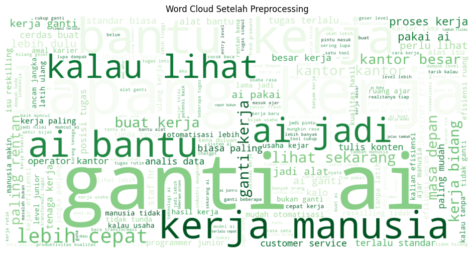

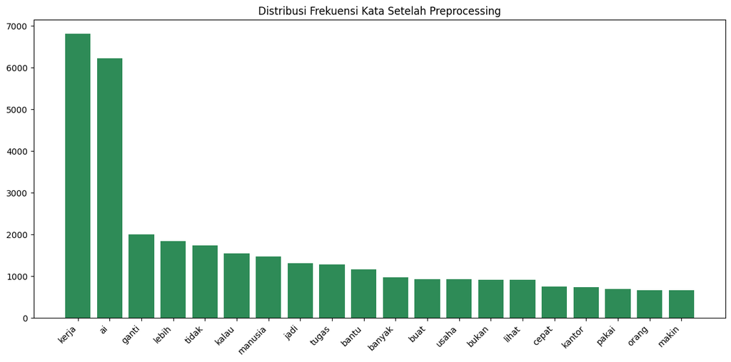

|  | kata | frekuensi |
| --- | --- | --- |
| 0 | kerja | 6805 |
| 1 | ai | 6231 |
| 2 | ganti | 2002 |
| 3 | lebih | 1847 |
| 4 | tidak | 1747 |
| 5 | kalau | 1546 |
| 6 | manusia | 1471 |
| 7 | jadi | 1317 |
| 8 | tugas | 1284 |
| 9 | bantu | 1170 |
| 10 | banyak | 970 |
| 11 | buat | 928 |
| 12 | usaha | 928 |
| 13 | bukan | 923 |
| 14 | lihat | 911 |
| 15 | cepat | 764 |
| 16 | kantor | 739 |
| 17 | pakai | 700 |
| 18 | orang | 667 |
| 19 | makin | 666 |

```python
# Menyiapkan visualisasi setelah preprocessing.

text_after = ' '.join(df['text_stemmed'].dropna().astype(str))
tokens_after = re.findall(r'\b\w+\b', text_after.lower())
freq_after = pd.DataFrame(Counter(tokens_after).most_common(20), columns=['kata', 'frekuensi'])

if WORDCLOUD_AVAILABLE:
    plt.figure(figsize=(12, 6))
    wc = WordCloud(width=1200, height=600, background_color='white', colormap='Greens').generate(text_after)
    plt.imshow(wc, interpolation='bilinear')
    plt.axis('off')
    plt.title('Word Cloud Setelah Preprocessing')
    plt.show()
else:
    print('WordCloud belum terpasang. Visual word cloud dilewati sementara.')

plt.figure(figsize=(12, 6))
plt.bar(freq_after['kata'], freq_after['frekuensi'], color='seagreen')
plt.title('Distribusi Frekuensi Kata Setelah Preprocessing')
plt.xticks(rotation=45, ha='right')
plt.tight_layout()
plt.show()

freq_after
```

## 4.9 Labeling

Setelah proses data cleansing dan preprocessing dasar disiapkan, tahap berikutnya adalah memastikan label klasifikasi yang digunakan sudah sesuai. Pada penelitian ini, label akhir mengacu pada kolom `manual_labeling` yang telah diisi secara manual.

Tiga label yang digunakan adalah:

- `ancaman`
- `peluang`
- `netral`

```python
# Menyiapkan label akhir dari hasil pelabelan manual.

df['label_final'] = df['manual_labeling'].astype(str).str.strip().str.lower()
df.loc[df['label_final'].isin(['', 'nan']), 'label_final'] = np.nan

print('Distribusi label manual:')
display(df['label_final'].value_counts(dropna=False))
```

```
Distribusi label manual:
```

```
label_final
netral     2070
ancaman    1723
peluang    1208
Name: count, dtype: int64
```

### 4.9.1 Visualisasi Distribusi Label

Setelah label akhir ditetapkan, distribusi setiap kelas ditampilkan dalam bentuk grafik batang. Visualisasi ini membantu melihat komposisi data pada masing-masing label sebelum data dibagi menjadi train dan test.

|  | label | jumlah |
| --- | --- | --- |
| 0 | netral | 2070 |
| 1 | ancaman | 1723 |
| 2 | peluang | 1208 |

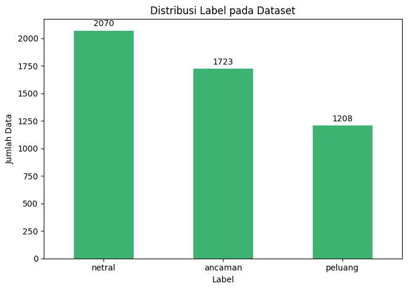

```python
# Grafik ini menunjukkan distribusi label pada seluruh dataset
# yang siap dipakai untuk tahap pemodelan.

label_distribution = df['label_final'].value_counts(dropna=False).dropna()
label_distribution = label_distribution.rename_axis('label').reset_index(name='jumlah')

display(label_distribution)

ax = label_distribution.plot(
    x='label',
    y='jumlah',
    kind='bar',
    figsize=(7, 5),
    color='mediumseagreen',
    legend=False
)

for container in ax.containers:
    ax.bar_label(container, padding=3)

plt.title('Distribusi Label pada Dataset')
plt.xlabel('Label')
plt.ylabel('Jumlah Data')
plt.xticks(rotation=0)
plt.tight_layout()
plt.show()
```

## 4.10 Data Splitting

Pembagian data dilakukan agar model dapat dilatih dan dievaluasi secara lebih adil. Pada penelitian ini, data dibagi menjadi tiga bagian, yaitu data train, validation, dan test.

Data train digunakan untuk melatih model. Data validation digunakan untuk memantau performa selama proses training dan memilih model terbaik pada fine-tuning transformer. Data test hanya digunakan pada evaluasi akhir agar hasil pengujian tidak ikut memengaruhi proses training.

Pembagian dilakukan secara stratified agar proporsi label pada data train, validation, dan test tetap seimbang.

```python
# Menyisakan data yang sudah memiliki label untuk tahap pemodelan.
# Split dibuat menjadi train/validation/test dengan proporsi 70/10/20.

RANDOM_STATE = 42
TEST_SIZE = 0.20
VALIDATION_SIZE_FROM_REMAINING = 0.125  # 12.5% dari sisa 80% = 10% dari total data
label_order = ['ancaman', 'peluang', 'netral']

df_model = df.dropna(subset=['label_final']).copy()

train_val_idx, test_idx = train_test_split(
    df_model.index,
    test_size=TEST_SIZE,
    random_state=RANDOM_STATE,
    stratify=df_model['label_final']
)

train_idx, val_idx = train_test_split(
    train_val_idx,
    test_size=VALIDATION_SIZE_FROM_REMAINING,
    random_state=RANDOM_STATE,
    stratify=df_model.loc[train_val_idx, 'label_final']
)

X_train_no_stem = df_model.loc[train_idx, 'text_no_stemming']
X_val_no_stem = df_model.loc[val_idx, 'text_no_stemming']
X_test_no_stem = df_model.loc[test_idx, 'text_no_stemming']

X_train_stem = df_model.loc[train_idx, 'text_stemmed']
X_val_stem = df_model.loc[val_idx, 'text_stemmed']
X_test_stem = df_model.loc[test_idx, 'text_stemmed']

y_train = df_model.loc[train_idx, 'label_final']
y_val = df_model.loc[val_idx, 'label_final']
y_test = df_model.loc[test_idx, 'label_final']

print('Jumlah data siap model:', len(df_model))
print('Ukuran data train     :', len(train_idx))
print('Ukuran data validation:', len(val_idx))
print('Ukuran data test      :', len(test_idx))
```

```
Jumlah data siap model: 5001
Ukuran data train     : 3500
Ukuran data validation: 500
Ukuran data test      : 1001
```

### 4.10.1 Visualisasi Distribusi Label pada Data Train, Validation, dan Test

Setelah data dibagi menjadi data train, validation, dan test, distribusi label ditampilkan kembali dalam bentuk visualisasi. Tujuannya adalah memastikan bahwa proses stratified split benar-benar menjaga proporsi kelas pada ketiga bagian data.

| label_final | train | validation | test |
| --- | --- | --- | --- |
| ancaman | 1206 | 172 | 345 |
| peluang | 845 | 121 | 242 |
| netral | 1449 | 207 | 414 |

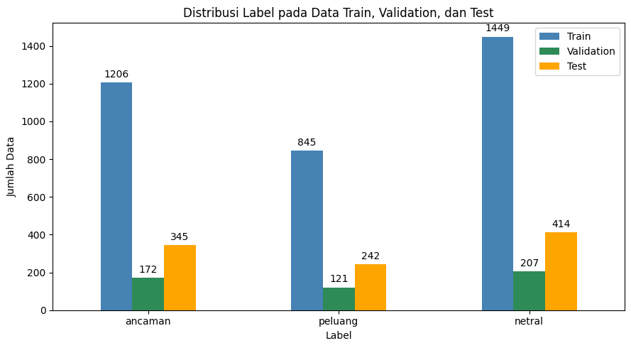

```python
# Visualisasi ini membantu melihat apakah distribusi label
# pada data train, validation, dan test tetap proporsional.

split_distribution = pd.DataFrame({
    'train': y_train.value_counts(),
    'validation': y_val.value_counts(),
    'test': y_test.value_counts()
}).fillna(0).astype(int)

split_distribution = split_distribution.loc[label_order]
display(split_distribution)

split_distribution_plot = split_distribution.reset_index()
split_distribution_plot.columns = ['label', 'train', 'validation', 'test']

ax = split_distribution_plot.plot(
    x='label',
    y=['train', 'validation', 'test'],
    kind='bar',
    figsize=(9, 5),
    color=['steelblue', 'seagreen', 'orange']
)

for container in ax.containers:
    ax.bar_label(container, padding=3)

plt.title('Distribusi Label pada Data Train, Validation, dan Test')
plt.xlabel('Label')
plt.ylabel('Jumlah Data')
plt.xticks(rotation=0)
plt.legend(['Train', 'Validation', 'Test'])
plt.tight_layout()
plt.show()
```

## 4.11 Feature Extraction TF-IDF

Pada tahap ini, teks yang telah dipreproses diubah menjadi fitur numerik menggunakan `TF-IDF`. Ekstraksi fitur dilakukan dalam dua skenario, yaitu teks tanpa stemming dan teks dengan stemming, agar pengaruh stemming terhadap representasi fitur dapat dibandingkan.

Proses ini dilakukan sebelum model `SVM` dilatih, karena `SVM` tidak membaca teks secara langsung, melainkan menggunakan masukan dalam bentuk fitur numerik.

```python
# TF-IDF mengubah teks menjadi fitur numerik untuk dua skenario.
# Skenario pertama memakai teks tanpa stemming.
# Skenario kedua memakai teks dengan stemming.

tfidf_no_stem = TfidfVectorizer(
    max_features=10000,
    ngram_range=(1, 2),
    min_df=2,
    sublinear_tf=True
)

tfidf_stem = TfidfVectorizer(
    max_features=10000,
    ngram_range=(1, 2),
    min_df=2,
    sublinear_tf=True
)

X_train_no_stem_tfidf = tfidf_no_stem.fit_transform(X_train_no_stem)
X_test_no_stem_tfidf = tfidf_no_stem.transform(X_test_no_stem)

X_train_stem_tfidf = tfidf_stem.fit_transform(X_train_stem)
X_test_stem_tfidf = tfidf_stem.transform(X_test_stem)

print('Bentuk fitur TF-IDF tanpa stemming:', X_train_no_stem_tfidf.shape)
print('Bentuk fitur TF-IDF dengan stemming:', X_train_stem_tfidf.shape)
```

```
Bentuk fitur TF-IDF tanpa stemming: (3500, 8404)
Bentuk fitur TF-IDF dengan stemming: (3500, 7867)
```

## 4.12 Modeling Baseline SVM

Setelah fitur TF-IDF diperoleh, tahap berikutnya adalah melatih model `SVM`. Pemodelan dilakukan pada dua skenario, yaitu menggunakan fitur hasil TF-IDF tanpa stemming dan fitur hasil TF-IDF dengan stemming.

Dengan pemisahan ini, peran `TF-IDF` sebagai ekstraksi fitur dan `SVM` sebagai classifier dapat terlihat lebih jelas.

```python
# SVM dilatih menggunakan fitur hasil TF-IDF.
# Dua model disiapkan untuk membandingkan skenario
# tanpa stemming dan dengan stemming.

svm_no_stem = LinearSVC(class_weight='balanced', random_state=42)
svm_no_stem.fit(X_train_no_stem_tfidf, y_train)
y_pred_no_stem = svm_no_stem.predict(X_test_no_stem_tfidf)
accuracy_no_stem = accuracy_score(y_test, y_pred_no_stem)

svm_stem = LinearSVC(class_weight='balanced', random_state=42)
svm_stem.fit(X_train_stem_tfidf, y_train)
y_pred_stem = svm_stem.predict(X_test_stem_tfidf)
accuracy_stem = accuracy_score(y_test, y_pred_stem)

hasil_baseline = pd.DataFrame([
    {'skenario': 'TF-IDF + SVM tanpa stemming', 'accuracy': accuracy_no_stem},
    {'skenario': 'TF-IDF + SVM dengan stemming', 'accuracy': accuracy_stem},
])

hasil_baseline
```

|  | skenario | accuracy |
| --- | --- | --- |
| 0 | TF-IDF + SVM tanpa stemming | 0.823177 |
| 1 | TF-IDF + SVM dengan stemming | 0.817183 |

## 4.13 Evaluasi Baseline TF-IDF + SVM

Setelah kedua skenario baseline dijalankan, hasil evaluasi dapat dibandingkan untuk melihat pengaruh stemming terhadap performa model. Evaluasi ditampilkan dalam bentuk classification report dan confusion matrix.

```
Accuracy tanpa stemming: 0.8232

Classification report tanpa stemming:
              precision    recall  f1-score   support

     ancaman       0.83      0.87      0.85       345
      netral       0.84      0.78      0.81       414
     peluang       0.79      0.83      0.81       242

    accuracy                           0.82      1001
   macro avg       0.82      0.83      0.82      1001
weighted avg       0.82      0.82      0.82      1001
```

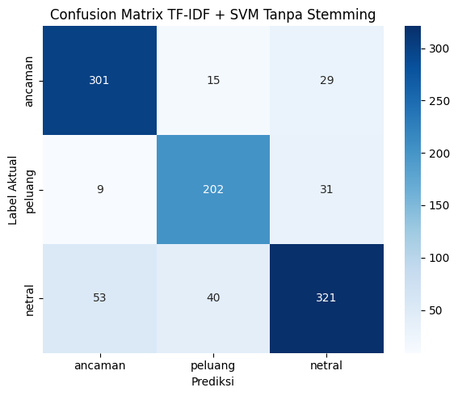

```
============================================================

Accuracy dengan stemming: 0.8172

Classification report dengan stemming:
              precision    recall  f1-score   support

     ancaman       0.82      0.88      0.85       345
      netral       0.85      0.76      0.80       414
     peluang       0.77      0.83      0.80       242

    accuracy                           0.82      1001
   macro avg       0.81      0.82      0.82      1001
weighted avg       0.82      0.82      0.82      1001
```

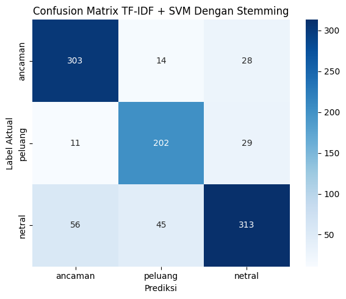

```python
# Menampilkan evaluasi rinci untuk kedua skenario baseline.

label_order = ['ancaman', 'peluang', 'netral']

def plot_confusion_matrix(cm, labels, title):
    plt.figure(figsize=(6, 5))
    if SEABORN_AVAILABLE:
        sns.heatmap(
            cm,
            annot=True,
            fmt='d',
            cmap='Blues',
            xticklabels=labels,
            yticklabels=labels
        )
    else:
        plt.imshow(cm, cmap='Blues')
        plt.colorbar()
        plt.xticks(range(len(labels)), labels)
        plt.yticks(range(len(labels)), labels)
        for i in range(cm.shape[0]):
            for j in range(cm.shape[1]):
                plt.text(j, i, cm[i, j], ha='center', va='center', color='black')
    plt.title(title)
    plt.xlabel('Prediksi')
    plt.ylabel('Label Aktual')
    plt.tight_layout()
    plt.show()

cm_no_stem = confusion_matrix(y_test, y_pred_no_stem, labels=label_order)
cm_stem = confusion_matrix(y_test, y_pred_stem, labels=label_order)

print('Accuracy tanpa stemming:', f'{accuracy_no_stem:.4f}')
print('\nClassification report tanpa stemming:')
print(classification_report(y_test, y_pred_no_stem))
plot_confusion_matrix(cm_no_stem, label_order, 'Confusion Matrix TF-IDF + SVM Tanpa Stemming')

print('\n' + '=' * 60 + '\n')

print('Accuracy dengan stemming:', f'{accuracy_stem:.4f}')
print('\nClassification report dengan stemming:')
print(classification_report(y_test, y_pred_stem))
plot_confusion_matrix(cm_stem, label_order, 'Confusion Matrix TF-IDF + SVM Dengan Stemming')
```

## 4.14 Fine-Tuning IndoBERT

Pada tahap ini, model transformer `IndoBERT` digunakan sebagai pembanding terhadap model baseline `TF-IDF + SVM`. Berbeda dengan baseline, masukan untuk IndoBERT tidak melalui preprocessing yang terlalu berat.

Teks yang dipakai untuk IndoBERT adalah teks hasil normalisasi ringan. Dengan cara ini, konteks kalimat masih tetap terjaga dan model dapat membaca susunan kata secara lebih alami.

### 4.14.1 Menyiapkan Teks dan Label untuk IndoBERT

Sebelum proses fine-tuning dilakukan, data perlu disiapkan terlebih dahulu. Pada tahap ini digunakan teks hasil normalisasi ringan yang disimpan dalam kolom `text_light_normalized`, lalu label `ancaman`, `peluang`, dan `netral` diubah ke bentuk numerik agar dapat dibaca model.

Pembagian data train, validation, dan test tetap memakai indeks yang sama seperti baseline. Hal ini dilakukan agar perbandingan hasil antar model tetap adil. Data validation dipakai selama training, sedangkan data test hanya dipakai untuk evaluasi akhir.

```python
# IndoBERT memakai teks hasil normalisasi ringan.
# Teks ini tidak melalui stopword removal, stemming,
# atau penyetaraan kata tidak baku yang lebih agresif.

df_model['text_for_indobert'] = df_model['text_light_normalized']

label2id = {'ancaman': 0, 'peluang': 1, 'netral': 2}
id2label = {v: k for k, v in label2id.items()}

train_indobert = df_model.loc[train_idx, ['text_for_indobert', 'label_final']].copy()
val_indobert = df_model.loc[val_idx, ['text_for_indobert', 'label_final']].copy()
test_indobert = df_model.loc[test_idx, ['text_for_indobert', 'label_final']].copy()

train_indobert['label_id'] = train_indobert['label_final'].map(label2id)
val_indobert['label_id'] = val_indobert['label_final'].map(label2id)
test_indobert['label_id'] = test_indobert['label_final'].map(label2id)

print('Jumlah data train IndoBERT     :', len(train_indobert))
print('Jumlah data validation IndoBERT:', len(val_indobert))
print('Jumlah data test IndoBERT      :', len(test_indobert))

display(train_indobert.head())
```

```
Jumlah data train IndoBERT     : 3500
Jumlah data validation IndoBERT: 500
Jumlah data test IndoBERT      : 1001
```

|  | text_for_indobert | label_final | label_id |
| --- | --- | --- | --- |
| 3507 | di kantor kantor besar diskusi soal ai dan akuntan sebaiknya tidak berhenti di pertanyaan diganti atau tidak karena dampaknya sangat bergantung pada jenis tugas konteks industri dan target organis... | netral | 2 |
| 3658 | buat yang kerja di bidang ini kalau organisasi mendukung pelatihan yang tepat ai bisa jadi pendorong peningkatan skill untuk pekerja penulis konten bukan ancaman yang harus ditakuti terus menerus ... | peluang | 1 |
| 796 | ini yg kaya nya ai ga ada menggantikan manusia ini diliat udh jelas ai itu akan menghilangkan ratusan pekerjaan yg dikerjaan manusia | peluang | 1 |
| 4932 | dampak ai terhadap customer service kemungkinan akan berbeda antara perusahaan besar startup dan organisasi publik karena pola adopsi teknologinya juga tidak sama perubahan ini lebih cocok dibaca ... | netral | 2 |
| 4608 | yang terlihat sekarang ai di pekerjaan operator kantor lebih mendorong redistribusi tugas pekerjaan dasar makin cepat sementara pekerjaan evaluatif justru jadi lebih penting maka analisisnya perlu... | netral | 2 |

### 4.14.2 Tokenisasi dengan Tokenizer Bawaan IndoBERT

Pada model `IndoBERT`, tokenisasi tidak dilakukan secara manual. Tokenisasi dilakukan menggunakan tokenizer bawaan model agar pemecahan token sesuai dengan vocabulary yang digunakan saat pretraining.

Model yang dipilih pada notebook ini adalah `indobenchmark/indobert-base-p1`. Jika library yang dibutuhkan belum tersedia, bagian ini dapat dijalankan setelah dependensi dipasang.

```python
# Tokenisasi dilakukan dengan tokenizer bawaan IndoBERT.
# Jika library transformers atau datasets belum tersedia,
# notebook akan memberi catatan tanpa menghentikan seluruh alur.

model_name_indobert = 'indobenchmark/indobert-base-p1'

try:
    from datasets import Dataset
    from transformers import AutoTokenizer

    tokenizer_indobert = AutoTokenizer.from_pretrained(model_name_indobert)

    train_dataset_indobert = Dataset.from_pandas(
        train_indobert[['text_for_indobert', 'label_id']].rename(
            columns={'text_for_indobert': 'text', 'label_id': 'label'}
        ),
        preserve_index=False
    )
    val_dataset_indobert = Dataset.from_pandas(
        val_indobert[['text_for_indobert', 'label_id']].rename(
            columns={'text_for_indobert': 'text', 'label_id': 'label'}
        ),
        preserve_index=False
    )
    test_dataset_indobert = Dataset.from_pandas(
        test_indobert[['text_for_indobert', 'label_id']].rename(
            columns={'text_for_indobert': 'text', 'label_id': 'label'}
        ),
        preserve_index=False
    )

    def tokenize_indobert(batch):
        return tokenizer_indobert(
            batch['text'],
            truncation=True,
            padding='max_length',
            max_length=128
        )

    tokenized_train_indobert = train_dataset_indobert.map(tokenize_indobert, batched=True)
    tokenized_val_indobert = val_dataset_indobert.map(tokenize_indobert, batched=True)
    tokenized_test_indobert = test_dataset_indobert.map(tokenize_indobert, batched=True)

    print('Tokenisasi IndoBERT berhasil disiapkan.')
    display(tokenized_train_indobert.select(range(min(3, len(tokenized_train_indobert)))))
except ImportError:
    print('Library transformers atau datasets belum terpasang. Tahap tokenisasi IndoBERT belum dijalankan.')
```

```
c:\Users\Mirza\OneDrive - Universitas Multimedia Nusantara\dataset skripsi\.venv\Lib\site-packages\tqdm\auto.py:21: TqdmWarning: IProgress not found. Please update jupyter and ipywidgets. See https://ipywidgets.readthedocs.io/en/stable/user_install.html
  from .autonotebook import tqdm as notebook_tqdm
```

```
Tokenisasi IndoBERT berhasil disiapkan.
```

```
Dataset({
    features: ['text', 'label', 'input_ids', 'token_type_ids', 'attention_mask'],
    num_rows: 3
})
```

### 4.14.3 Menyiapkan Fine-Tuning IndoBERT

Setelah tokenisasi selesai, model `IndoBERT` dapat di-fine-tune menggunakan data train. Selama training, data validation digunakan untuk mengevaluasi performa tiap epoch dan memilih checkpoint terbaik. Data test tidak digunakan pada tahap ini agar evaluasi akhir tetap adil.

Parameter pelatihan pada notebook ini disiapkan sebagai titik awal. Nilainya masih dapat disesuaikan kembali jika pada proses eksperimen diperlukan penyesuaian yang lebih lanjut.

```python
# Fine-tuning IndoBERT disiapkan dengan Trainer dari Hugging Face.
# Eval dataset memakai validation set, bukan test set.

indobert_trainer = None
accuracy_indobert = np.nan
y_pred_indobert = None
y_test_indobert = test_indobert['label_final'].tolist()

try:
    from transformers import AutoModelForSequenceClassification, TrainingArguments, Trainer

    model_indobert = AutoModelForSequenceClassification.from_pretrained(
        model_name_indobert,
        num_labels=len(label2id),
        id2label=id2label,
        label2id=label2id
    )

    training_args_indobert = TrainingArguments(
        output_dir='outputs/indobert_results',
        eval_strategy='epoch',
        save_strategy='epoch',
        logging_strategy='epoch',
        learning_rate=2e-5,
        per_device_train_batch_size=8,
        per_device_eval_batch_size=8,
        num_train_epochs=3,
        weight_decay=0.01,
        load_best_model_at_end=True,
        metric_for_best_model='accuracy',
        save_total_limit=1,
        report_to='none'
    )

    def compute_metrics_indobert(eval_pred):
        logits, labels = eval_pred
        predictions = np.argmax(logits, axis=1)
        return {'accuracy': accuracy_score(labels, predictions)}

    indobert_trainer = Trainer(
        model=model_indobert,
        args=training_args_indobert,
        train_dataset=tokenized_train_indobert,
        eval_dataset=tokenized_val_indobert,
        processing_class=tokenizer_indobert,
        compute_metrics=compute_metrics_indobert
    )

    print('Trainer IndoBERT sudah siap. Jalankan baris berikut saat ingin memulai training:')
    print('indobert_trainer.train()')
except Exception as e:
    print('Trainer IndoBERT belum siap dijalankan:', e)
```

```
Trainer IndoBERT sudah siap. Jalankan baris berikut saat ingin memulai training:
indobert_trainer.train()
```

### 4.14.4 Menjalankan Training IndoBERT

Setelah `Trainer` berhasil disiapkan, proses berikutnya adalah menjalankan training pada data train. Pada tahap ini, bobot classifier yang sebelumnya masih baru akan mulai menyesuaikan diri dengan pola data pada penelitian.

Durasi training dapat berbeda-beda tergantung kemampuan perangkat yang digunakan. Setelah training selesai, hasil evaluasi akhir dapat dijalankan pada bagian berikutnya.

```python
# Cell ini dipakai untuk menjalankan training IndoBERT.
# Jalankan setelah trainer berhasil disiapkan.

if indobert_trainer is None:
    print('Trainer IndoBERT belum siap. Jalankan tahap persiapan trainer terlebih dahulu.')
else:
    train_result_indobert = indobert_trainer.train()
    print('Training IndoBERT selesai.')
    train_result_indobert
```

```
c:\Users\Mirza\OneDrive - Universitas Multimedia Nusantara\dataset skripsi\.venv\Lib\site-packages\torch\utils\data\dataloader.py:775: UserWarning: 'pin_memory' argument is set as true but no accelerator is found, then device pinned memory won't be used.
  super().__init__(loader)
```

[1314/1314 1:14:57, Epoch 3/3]

| Epoch | Training Loss | Validation Loss | Accuracy |
| --- | --- | --- | --- |
| 1 | 0.619223 | 0.445345 | 0.832000 |
| 2 | 0.390263 | 0.430128 | 0.866000 |
| 3 | 0.267085 | 0.479817 | 0.858000 |

[output not shown]

```
Training IndoBERT selesai.
```

### 4.14.5 Evaluasi IndoBERT

Setelah proses fine-tuning selesai, hasil prediksi pada data test dapat dievaluasi menggunakan metrik yang sama seperti baseline. Dengan demikian, hasil `IndoBERT` dapat dibandingkan secara langsung terhadap `TF-IDF + SVM`.

Visualisasi confusion matrix juga dapat digunakan agar pola prediksi yang benar dan salah lebih mudah diamati.

```
c:\Users\Mirza\OneDrive - Universitas Multimedia Nusantara\dataset skripsi\.venv\Lib\site-packages\torch\utils\data\dataloader.py:775: UserWarning: 'pin_memory' argument is set as true but no accelerator is found, then device pinned memory won't be used.
  super().__init__(loader)
```

```
Accuracy IndoBERT: 0.8492

Classification report IndoBERT:
              precision    recall  f1-score   support

     ancaman       0.82      0.93      0.87       345
      netral       0.87      0.81      0.84       414
     peluang       0.86      0.81      0.83       242

    accuracy                           0.85      1001
   macro avg       0.85      0.85      0.85      1001
weighted avg       0.85      0.85      0.85      1001
```

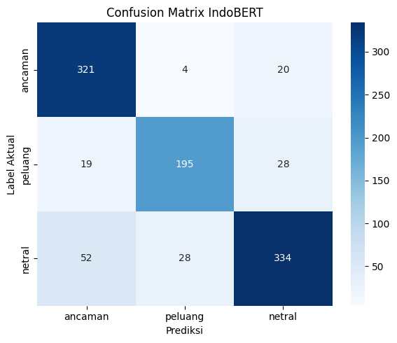

```python
# Cell ini dijalankan setelah proses training selesai.
# Jika trainer belum dijalankan, notebook hanya menampilkan pengingat singkat.

if indobert_trainer is None:
    print('Trainer IndoBERT belum siap. Lengkapi tahap tokenisasi dan inisialisasi model terlebih dahulu.')
else:
    if not hasattr(indobert_trainer, 'state') or indobert_trainer.state.global_step == 0:
        print('Silakan jalankan indobert_trainer.train() terlebih dahulu sebelum evaluasi akhir.')
    else:
        pred_output_indobert = indobert_trainer.predict(tokenized_test_indobert)
        pred_ids_indobert = np.argmax(pred_output_indobert.predictions, axis=1)
        y_pred_indobert = [id2label[i] for i in pred_ids_indobert]
        accuracy_indobert = accuracy_score(y_test_indobert, y_pred_indobert)

        print('Accuracy IndoBERT:', f'{accuracy_indobert:.4f}')
        print('\nClassification report IndoBERT:')
        print(classification_report(y_test_indobert, y_pred_indobert))

        cm_indobert = confusion_matrix(y_test_indobert, y_pred_indobert, labels=label_order)
        plot_confusion_matrix(cm_indobert, label_order, 'Confusion Matrix IndoBERT')
```

## 4.15 Fine-Tuning IndoBERTweet

Pada tahap ini, model `IndoBERTweet` digunakan sebagai pembanding lanjutan karena model ini memang dikembangkan untuk data bergaya media sosial. Dengan karakter tersebut, IndoBERTweet diharapkan lebih peka terhadap bentuk bahasa tweet yang cenderung singkat, tidak selalu formal, dan kadang memakai variasi penulisan.

Seperti pada IndoBERT, masukan untuk IndoBERTweet tetap menggunakan teks hasil normalisasi ringan agar konteks kalimat tetap terjaga.

### 4.15.1 Menyiapkan Teks dan Label untuk IndoBERTweet

Data yang digunakan pada tahap ini tetap berasal dari dataset dan split yang sama seperti model sebelumnya. Tujuannya agar hasil evaluasi antara baseline, IndoBERT, dan IndoBERTweet dapat dibandingkan secara adil.

Teks input diambil dari kolom `text_light_normalized`, sedangkan label tetap menggunakan hasil `manual_labeling` yang telah dipetakan ke bentuk numerik. Data validation dipakai selama training, sedangkan data test hanya dipakai pada evaluasi akhir.

```python
# IndoBERTweet juga memakai teks hasil normalisasi ringan.
# Split data tetap sama agar perbandingan antar model adil.

df_model['text_for_indobertweet'] = df_model['text_light_normalized']

train_indobertweet = df_model.loc[train_idx, ['text_for_indobertweet', 'label_final']].copy()
val_indobertweet = df_model.loc[val_idx, ['text_for_indobertweet', 'label_final']].copy()
test_indobertweet = df_model.loc[test_idx, ['text_for_indobertweet', 'label_final']].copy()

train_indobertweet['label_id'] = train_indobertweet['label_final'].map(label2id)
val_indobertweet['label_id'] = val_indobertweet['label_final'].map(label2id)
test_indobertweet['label_id'] = test_indobertweet['label_final'].map(label2id)

print('Jumlah data train IndoBERTweet     :', len(train_indobertweet))
print('Jumlah data validation IndoBERTweet:', len(val_indobertweet))
print('Jumlah data test IndoBERTweet      :', len(test_indobertweet))

display(train_indobertweet.head())
```

```
Jumlah data train IndoBERTweet     : 3500
Jumlah data validation IndoBERTweet: 500
Jumlah data test IndoBERTweet      : 1001
```

|  | text_for_indobertweet | label_final | label_id |
| --- | --- | --- | --- |
| 3507 | di kantor kantor besar diskusi soal ai dan akuntan sebaiknya tidak berhenti di pertanyaan diganti atau tidak karena dampaknya sangat bergantung pada jenis tugas konteks industri dan target organis... | netral | 2 |
| 3658 | buat yang kerja di bidang ini kalau organisasi mendukung pelatihan yang tepat ai bisa jadi pendorong peningkatan skill untuk pekerja penulis konten bukan ancaman yang harus ditakuti terus menerus ... | peluang | 1 |
| 796 | ini yg kaya nya ai ga ada menggantikan manusia ini diliat udh jelas ai itu akan menghilangkan ratusan pekerjaan yg dikerjaan manusia | peluang | 1 |
| 4932 | dampak ai terhadap customer service kemungkinan akan berbeda antara perusahaan besar startup dan organisasi publik karena pola adopsi teknologinya juga tidak sama perubahan ini lebih cocok dibaca ... | netral | 2 |
| 4608 | yang terlihat sekarang ai di pekerjaan operator kantor lebih mendorong redistribusi tugas pekerjaan dasar makin cepat sementara pekerjaan evaluatif justru jadi lebih penting maka analisisnya perlu... | netral | 2 |

### 4.15.2 Tokenisasi dengan Tokenizer Bawaan IndoBERTweet

Tokenisasi pada IndoBERTweet dilakukan menggunakan tokenizer bawaan model. Langkah ini penting karena vocabulary dan cara pemotongan token pada IndoBERTweet berbeda dari IndoBERT biasa.

Model yang dipakai pada notebook ini adalah `indolem/indobertweet-base-uncased`. Jika dependensinya sudah tersedia, tahap tokenisasi dapat dijalankan langsung pada notebook.

```python
# Tokenisasi dilakukan dengan tokenizer bawaan IndoBERTweet.
# Struktur langkahnya dibuat mirip dengan IndoBERT agar lebih mudah dibandingkan.

model_name_indobertweet = 'indolem/indobertweet-base-uncased'

try:
    from datasets import Dataset
    from transformers import AutoTokenizer

    tokenizer_indobertweet = AutoTokenizer.from_pretrained(model_name_indobertweet)

    train_dataset_indobertweet = Dataset.from_pandas(
        train_indobertweet[['text_for_indobertweet', 'label_id']].rename(
            columns={'text_for_indobertweet': 'text', 'label_id': 'label'}
        ),
        preserve_index=False
    )
    val_dataset_indobertweet = Dataset.from_pandas(
        val_indobertweet[['text_for_indobertweet', 'label_id']].rename(
            columns={'text_for_indobertweet': 'text', 'label_id': 'label'}
        ),
        preserve_index=False
    )
    test_dataset_indobertweet = Dataset.from_pandas(
        test_indobertweet[['text_for_indobertweet', 'label_id']].rename(
            columns={'text_for_indobertweet': 'text', 'label_id': 'label'}
        ),
        preserve_index=False
    )

    def tokenize_indobertweet(batch):
        return tokenizer_indobertweet(
            batch['text'],
            truncation=True,
            padding='max_length',
            max_length=128
        )

    tokenized_train_indobertweet = train_dataset_indobertweet.map(tokenize_indobertweet, batched=True)
    tokenized_val_indobertweet = val_dataset_indobertweet.map(tokenize_indobertweet, batched=True)
    tokenized_test_indobertweet = test_dataset_indobertweet.map(tokenize_indobertweet, batched=True)

    print('Tokenisasi IndoBERTweet berhasil disiapkan.')
    display(tokenized_train_indobertweet.select(range(min(3, len(tokenized_train_indobertweet)))))
except ImportError:
    print('Library transformers atau datasets belum terpasang. Tahap tokenisasi IndoBERTweet belum dijalankan.')
```

```
Tokenisasi IndoBERTweet berhasil disiapkan.
```

```
Dataset({
    features: ['text', 'label', 'input_ids', 'token_type_ids', 'attention_mask'],
    num_rows: 3
})
```

### 4.15.3 Menyiapkan Fine-Tuning IndoBERTweet

Setelah tokenisasi selesai, model IndoBERTweet disiapkan untuk proses fine-tuning. Parameter awal yang digunakan dibuat serupa dengan IndoBERT agar perbandingan performa lebih mudah dilakukan. Sama seperti IndoBERT, data validation digunakan saat training dan data test disimpan untuk evaluasi akhir.

Jika pada pelaksanaan eksperimen dibutuhkan penyesuaian, nilai parameter seperti `num_train_epochs`, `learning_rate`, atau `batch_size` masih dapat diubah kembali.

```python
# Fine-tuning IndoBERTweet disiapkan dengan Trainer yang terpisah
# dari IndoBERT karena model dan tokenizer yang dipakai juga berbeda.
# Eval dataset memakai validation set, bukan test set.

indobertweet_trainer = None
accuracy_indobertweet = np.nan
y_pred_indobertweet = None
y_test_indobertweet = test_indobertweet['label_final'].tolist()

try:
    from transformers import AutoModelForSequenceClassification, TrainingArguments, Trainer

    model_indobertweet = AutoModelForSequenceClassification.from_pretrained(
        model_name_indobertweet,
        num_labels=len(label2id),
        id2label=id2label,
        label2id=label2id
    )

    training_args_indobertweet = TrainingArguments(
        output_dir='outputs/indobertweet_results',
        eval_strategy='epoch',
        save_strategy='epoch',
        logging_strategy='epoch',
        learning_rate=2e-5,
        per_device_train_batch_size=8,
        per_device_eval_batch_size=8,
        num_train_epochs=3,
        weight_decay=0.01,
        load_best_model_at_end=True,
        metric_for_best_model='accuracy',
        save_total_limit=1,
        report_to='none'
    )

    def compute_metrics_indobertweet(eval_pred):
        logits, labels = eval_pred
        predictions = np.argmax(logits, axis=1)
        return {'accuracy': accuracy_score(labels, predictions)}

    indobertweet_trainer = Trainer(
        model=model_indobertweet,
        args=training_args_indobertweet,
        train_dataset=tokenized_train_indobertweet,
        eval_dataset=tokenized_val_indobertweet,
        processing_class=tokenizer_indobertweet,
        compute_metrics=compute_metrics_indobertweet
    )

    print('Trainer IndoBERTweet sudah siap. Jalankan cell training pada tahap berikutnya.')
except Exception as e:
    print('Trainer IndoBERTweet belum siap dijalankan:', e)
```

[output not shown]

```
Trainer IndoBERTweet sudah siap. Jalankan cell training pada tahap berikutnya.
```

### 4.15.4 Menjalankan Training IndoBERTweet

Pada tahap ini, model IndoBERTweet mulai dilatih menggunakan data train. Proses ini akan memperbarui bobot classifier agar sesuai dengan karakter data pada penelitian.

Waktu training dapat bervariasi tergantung kemampuan perangkat, jumlah epoch, dan panjang input token yang digunakan.

```python
# Cell ini dipakai untuk menjalankan training IndoBERTweet.
# Jalankan setelah trainer berhasil disiapkan.

if indobertweet_trainer is None:
    print('Trainer IndoBERTweet belum siap. Jalankan tahap persiapan trainer terlebih dahulu.')
else:
    train_result_indobertweet = indobertweet_trainer.train()
    print('Training IndoBERTweet selesai.')
    train_result_indobertweet
```

```
The tokenizer has new PAD/BOS/EOS tokens that differ from the model config and generation config. The model config and generation config were aligned accordingly, being updated with the tokenizer's values. Updated tokens: {'bos_token_id': None}.
c:\Users\Mirza\OneDrive - Universitas Multimedia Nusantara\dataset skripsi\.venv\Lib\site-packages\torch\utils\data\dataloader.py:775: UserWarning: 'pin_memory' argument is set as true but no accelerator is found, then device pinned memory won't be used.
  super().__init__(loader)
```

[1314/1314 1:13:55, Epoch 3/3]

| Epoch | Training Loss | Validation Loss | Accuracy |
| --- | --- | --- | --- |
| 1 | 0.698857 | 0.556220 | 0.780000 |
| 2 | 0.422145 | 0.472993 | 0.842000 |
| 3 | 0.298713 | 0.499404 | 0.844000 |

[output not shown]

```
Training IndoBERTweet selesai.
```

### 4.15.5 Evaluasi IndoBERTweet

Setelah training selesai, hasil prediksi model pada data test dievaluasi dengan metrik yang sama seperti model sebelumnya. Dengan demikian, hasil IndoBERTweet dapat dibandingkan secara langsung terhadap baseline dan IndoBERT.

Confusion matrix divisualisasikan kembali agar distribusi prediksi yang benar dan yang keliru dapat diamati dengan lebih mudah.

```
c:\Users\Mirza\OneDrive - Universitas Multimedia Nusantara\dataset skripsi\.venv\Lib\site-packages\torch\utils\data\dataloader.py:775: UserWarning: 'pin_memory' argument is set as true but no accelerator is found, then device pinned memory won't be used.
  super().__init__(loader)
```

```
Accuracy IndoBERTweet: 0.8332

Classification report IndoBERTweet:
              precision    recall  f1-score   support

     ancaman       0.84      0.88      0.86       345
      netral       0.86      0.78      0.82       414
     peluang       0.79      0.86      0.82       242

    accuracy                           0.83      1001
   macro avg       0.83      0.84      0.83      1001
weighted avg       0.83      0.83      0.83      1001
```

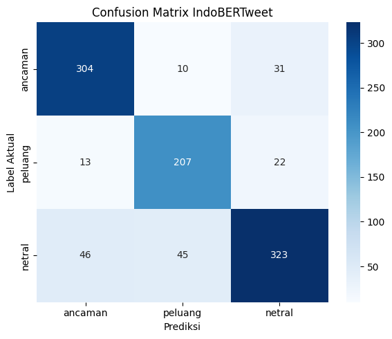

```python
# Cell ini dijalankan setelah proses training selesai.
# Jika trainer belum dijalankan, notebook hanya menampilkan pengingat singkat.

if indobertweet_trainer is None:
    print('Trainer IndoBERTweet belum siap. Lengkapi tahap tokenisasi dan inisialisasi model terlebih dahulu.')
else:
    if not hasattr(indobertweet_trainer, 'state') or indobertweet_trainer.state.global_step == 0:
        print('Silakan jalankan cell training IndoBERTweet terlebih dahulu sebelum evaluasi akhir.')
    else:
        pred_output_indobertweet = indobertweet_trainer.predict(tokenized_test_indobertweet)
        pred_ids_indobertweet = np.argmax(pred_output_indobertweet.predictions, axis=1)
        y_pred_indobertweet = [id2label[i] for i in pred_ids_indobertweet]
        accuracy_indobertweet = accuracy_score(y_test_indobertweet, y_pred_indobertweet)

        print('Accuracy IndoBERTweet:', f'{accuracy_indobertweet:.4f}')
        print('\nClassification report IndoBERTweet:')
        print(classification_report(y_test_indobertweet, y_pred_indobertweet))

        cm_indobertweet = confusion_matrix(y_test_indobertweet, y_pred_indobertweet, labels=label_order)
        plot_confusion_matrix(cm_indobertweet, label_order, 'Confusion Matrix IndoBERTweet')
```

### 4.15.6 Skenario Pembanding IndoBERTweet tanpa Normalisasi

Untuk melihat apakah proses normalisasi memengaruhi performa IndoBERTweet, dibuat satu skenario pembanding tambahan. Pada skenario ini, teks yang dipakai lebih mendekati bentuk aslinya, yaitu langsung dari kolom `full_text` dengan pembersihan yang sangat ringan.

Tujuan langkah ini adalah membandingkan apakah IndoBERTweet bekerja lebih baik saat karakter asli tweet masih dipertahankan.

```python
# Skenario pembanding ini memakai teks yang lebih dekat ke bentuk tweet asli.
# Pembersihan hanya dilakukan secara ringan agar karakter teks tetap terjaga.

def prepare_raw_tweet_text(text):
    text = str(text)
    text = re.sub(r'\s+', ' ', text).strip()
    return text

df_model['text_for_indobertweet_raw'] = df_model['full_text'].apply(prepare_raw_tweet_text)

train_indobertweet_raw = df_model.loc[train_idx, ['text_for_indobertweet_raw', 'label_final']].copy()
val_indobertweet_raw = df_model.loc[val_idx, ['text_for_indobertweet_raw', 'label_final']].copy()
test_indobertweet_raw = df_model.loc[test_idx, ['text_for_indobertweet_raw', 'label_final']].copy()

train_indobertweet_raw['label_id'] = train_indobertweet_raw['label_final'].map(label2id)
val_indobertweet_raw['label_id'] = val_indobertweet_raw['label_final'].map(label2id)
test_indobertweet_raw['label_id'] = test_indobertweet_raw['label_final'].map(label2id)

display(train_indobertweet_raw.head())
```

|  | text_for_indobertweet_raw | label_final | label_id |
| --- | --- | --- | --- |
| 3507 | Di kantor-kantor besar, diskusi soal AI dan akuntan sebaiknya tidak berhenti di pertanyaan diganti atau tidak, karena dampaknya sangat bergantung pada jenis tugas, konteks industri, dan target org... | netral | 2 |
| 3658 | Buat yang kerja di bidang ini, kalau organisasi mendukung pelatihan yang tepat, AI bisa jadi pendorong peningkatan skill untuk pekerja penulis konten, bukan ancaman yang harus ditakuti terus-mener... | peluang | 1 |
| 796 | @blue_berets7 Ini yg kaya nya AI ga ada menggantikan manusia @gibran_tweet .. Ini diliat udh jelas AI itu akan menghilangkan ratusan pekerjaan yg dikerjaan manusia. | peluang | 1 |
| 4932 | dampak AI terhadap customer service kemungkinan akan berbeda antara perusahaan besar, startup, dan organisasi publik karena pola adopsi teknologinya juga tidak sama. Perubahan ini lebih cocok diba... | netral | 2 |
| 4608 | @worktrenddaily yang terlihat sekarang, AI di pekerjaan operator kantor lebih mendorong redistribusi tugas: pekerjaan dasar makin cepat, sementara pekerjaan evaluatif justru jadi lebih penting. Ma... | netral | 2 |

### 4.15.7 Tokenisasi dan Trainer untuk Skenario Pembanding

Langkah tokenisasi dan penyiapan trainer pada skenario pembanding dibuat terpisah dari skenario utama. Hal ini dilakukan agar hasil eksperimen tidak saling menimpa dan tetap mudah dibandingkan.

```python
# Tokenisasi dan trainer untuk skenario pembanding disiapkan terpisah.

indobertweet_raw_trainer = None
accuracy_indobertweet_raw = np.nan
y_pred_indobertweet_raw = None
y_test_indobertweet_raw = test_indobertweet_raw['label_final'].tolist()

try:
    from datasets import Dataset
    from transformers import AutoTokenizer, AutoModelForSequenceClassification, TrainingArguments, Trainer

    tokenizer_indobertweet_raw = AutoTokenizer.from_pretrained(model_name_indobertweet)

    train_dataset_indobertweet_raw = Dataset.from_pandas(
        train_indobertweet_raw[['text_for_indobertweet_raw', 'label_id']].rename(
            columns={'text_for_indobertweet_raw': 'text', 'label_id': 'label'}
        ),
        preserve_index=False
    )
    val_dataset_indobertweet_raw = Dataset.from_pandas(
        val_indobertweet_raw[['text_for_indobertweet_raw', 'label_id']].rename(
            columns={'text_for_indobertweet_raw': 'text', 'label_id': 'label'}
        ),
        preserve_index=False
    )
    test_dataset_indobertweet_raw = Dataset.from_pandas(
        test_indobertweet_raw[['text_for_indobertweet_raw', 'label_id']].rename(
            columns={'text_for_indobertweet_raw': 'text', 'label_id': 'label'}
        ),
        preserve_index=False
    )

    def tokenize_indobertweet_raw(batch):
        return tokenizer_indobertweet_raw(
            batch['text'],
            truncation=True,
            padding='max_length',
            max_length=128
        )

    tokenized_train_indobertweet_raw = train_dataset_indobertweet_raw.map(tokenize_indobertweet_raw, batched=True)
    tokenized_val_indobertweet_raw = val_dataset_indobertweet_raw.map(tokenize_indobertweet_raw, batched=True)
    tokenized_test_indobertweet_raw = test_dataset_indobertweet_raw.map(tokenize_indobertweet_raw, batched=True)

    model_indobertweet_raw = AutoModelForSequenceClassification.from_pretrained(
        model_name_indobertweet,
        num_labels=len(label2id),
        id2label=id2label,
        label2id=label2id
    )

    training_args_indobertweet_raw = TrainingArguments(
        output_dir='outputs/indobertweet_raw_results',
        eval_strategy='epoch',
        save_strategy='epoch',
        logging_strategy='epoch',
        learning_rate=2e-5,
        per_device_train_batch_size=8,
        per_device_eval_batch_size=8,
        num_train_epochs=3,
        weight_decay=0.01,
        load_best_model_at_end=True,
        metric_for_best_model='accuracy',
        save_total_limit=1,
        report_to='none'
    )

    def compute_metrics_indobertweet_raw(eval_pred):
        logits, labels = eval_pred
        predictions = np.argmax(logits, axis=1)
        return {'accuracy': accuracy_score(labels, predictions)}

    indobertweet_raw_trainer = Trainer(
        model=model_indobertweet_raw,
        args=training_args_indobertweet_raw,
        train_dataset=tokenized_train_indobertweet_raw,
        eval_dataset=tokenized_val_indobertweet_raw,
        processing_class=tokenizer_indobertweet_raw,
        compute_metrics=compute_metrics_indobertweet_raw
    )

    print('Trainer IndoBERTweet skenario pembanding sudah siap.')
except Exception as e:
    print('Skenario pembanding IndoBERTweet belum siap dijalankan:', e)
```

[output not shown]

```
Trainer IndoBERTweet skenario pembanding sudah siap.
```

### 4.15.8 Menjalankan Training Skenario Pembanding

Setelah trainer pembanding siap, training dapat dijalankan dengan langkah yang sama seperti skenario utama. Hasil dari skenario ini nantinya dibandingkan dengan IndoBERTweet yang memakai teks hasil normalisasi.

```python
# Jalankan training untuk skenario IndoBERTweet tanpa normalisasi.

if indobertweet_raw_trainer is None:
    print('Trainer pembanding belum siap. Jalankan tahap persiapan terlebih dahulu.')
else:
    train_result_indobertweet_raw = indobertweet_raw_trainer.train()
    print('Training IndoBERTweet skenario pembanding selesai.')
    train_result_indobertweet_raw
```

```
The tokenizer has new PAD/BOS/EOS tokens that differ from the model config and generation config. The model config and generation config were aligned accordingly, being updated with the tokenizer's values. Updated tokens: {'bos_token_id': None}.
c:\Users\Mirza\OneDrive - Universitas Multimedia Nusantara\dataset skripsi\.venv\Lib\site-packages\torch\utils\data\dataloader.py:775: UserWarning: 'pin_memory' argument is set as true but no accelerator is found, then device pinned memory won't be used.
  super().__init__(loader)
```

[1314/1314 1:10:49, Epoch 3/3]

| Epoch | Training Loss | Validation Loss | Accuracy |
| --- | --- | --- | --- |
| 1 | 0.691702 | 0.533993 | 0.794000 |
| 2 | 0.405936 | 0.464697 | 0.852000 |
| 3 | 0.284906 | 0.491821 | 0.856000 |

[output not shown]

```
Training IndoBERTweet skenario pembanding selesai.
```

### 4.15.9 Evaluasi Skenario Pembanding

Tahap ini digunakan untuk melihat hasil akhir dari IndoBERTweet yang memakai teks lebih dekat ke bentuk aslinya. Hasil evaluasi dapat dibandingkan dengan skenario utama untuk melihat pengaruh normalisasi terhadap performa model.

```
c:\Users\Mirza\OneDrive - Universitas Multimedia Nusantara\dataset skripsi\.venv\Lib\site-packages\torch\utils\data\dataloader.py:775: UserWarning: 'pin_memory' argument is set as true but no accelerator is found, then device pinned memory won't be used.
  super().__init__(loader)
```

```
Accuracy IndoBERTweet tanpa normalisasi: 0.8312

Classification report IndoBERTweet tanpa normalisasi:
              precision    recall  f1-score   support

     ancaman       0.83      0.89      0.86       345
      netral       0.87      0.77      0.81       414
     peluang       0.78      0.86      0.82       242

    accuracy                           0.83      1001
   macro avg       0.83      0.84      0.83      1001
weighted avg       0.83      0.83      0.83      1001
```

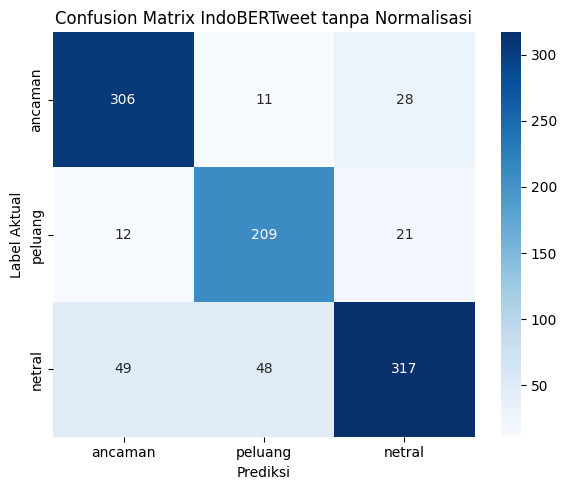

```python
# Evaluasi akhir untuk skenario pembanding IndoBERTweet.

if indobertweet_raw_trainer is None:
    print('Trainer pembanding belum siap. Lengkapi tahap sebelumnya terlebih dahulu.')
else:
    if not hasattr(indobertweet_raw_trainer, 'state') or indobertweet_raw_trainer.state.global_step == 0:
        print('Silakan jalankan cell training skenario pembanding terlebih dahulu sebelum evaluasi akhir.')
    else:
        pred_output_indobertweet_raw = indobertweet_raw_trainer.predict(tokenized_test_indobertweet_raw)
        pred_ids_indobertweet_raw = np.argmax(pred_output_indobertweet_raw.predictions, axis=1)
        y_pred_indobertweet_raw = [id2label[i] for i in pred_ids_indobertweet_raw]
        accuracy_indobertweet_raw = accuracy_score(y_test_indobertweet_raw, y_pred_indobertweet_raw)

        print('Accuracy IndoBERTweet tanpa normalisasi:', f'{accuracy_indobertweet_raw:.4f}')
        print('\nClassification report IndoBERTweet tanpa normalisasi:')
        print(classification_report(y_test_indobertweet_raw, y_pred_indobertweet_raw))

        cm_indobertweet_raw = confusion_matrix(y_test_indobertweet_raw, y_pred_indobertweet_raw, labels=label_order)
        plot_confusion_matrix(cm_indobertweet_raw, label_order, 'Confusion Matrix IndoBERTweet tanpa Normalisasi')
```

## 4.16 Rekap Evaluasi Model

```python
# Tabel rekap bisa diisi bertahap sesuai hasil eksperimen.

hasil_model = pd.DataFrame([
    {
        'model': 'TF-IDF + SVM tanpa stemming',
        'accuracy': accuracy_no_stem if 'accuracy_no_stem' in globals() else np.nan,
        'catatan': 'Baseline tanpa stemming'
    },
    {
        'model': 'TF-IDF + SVM dengan stemming',
        'accuracy': accuracy_stem if 'accuracy_stem' in globals() else np.nan,
        'catatan': 'Baseline dengan stemming'
    },
    {
        'model': 'IndoBERT',
        'accuracy': accuracy_indobert if 'accuracy_indobert' in globals() else np.nan,
        'catatan': 'Fine-tuning IndoBERT; validation dipakai saat training, test untuk evaluasi akhir'
    },
    {
        'model': 'IndoBERTweet',
        'accuracy': accuracy_indobertweet if 'accuracy_indobertweet' in globals() else np.nan,
        'catatan': 'Fine-tuning IndoBERTweet dengan text_light_normalized'
    },
    {
        'model': 'IndoBERTweet tanpa normalisasi',
        'accuracy': accuracy_indobertweet_raw if 'accuracy_indobertweet_raw' in globals() else np.nan,
        'catatan': 'Fine-tuning IndoBERTweet dengan full_text'
    }
])

hasil_model
```

|  | model | accuracy | catatan |
| --- | --- | --- | --- |
| 0 | TF-IDF + SVM tanpa stemming | 0.823177 | Baseline tanpa stemming |
| 1 | TF-IDF + SVM dengan stemming | 0.817183 | Baseline dengan stemming |
| 2 | IndoBERT | 0.849151 | Fine-tuning IndoBERT; validation dipakai saat training, test untuk evaluasi akhir |
| 3 | IndoBERTweet | 0.833167 | Fine-tuning IndoBERTweet dengan text_light_normalized |
| 4 | IndoBERTweet tanpa normalisasi | 0.831169 | Fine-tuning IndoBERTweet dengan full_text |